# ML_HW3

2022-10-25

```r
library(tidyverse)
library(tidymodels)
library(discrim)
library(corrplot)
library(klaR)

set.seed(17)

titanic <- read.csv("titanic.csv")

titanic$survived <- as.factor(titanic$survived)
titanic$pclass <- as.factor(titanic$pclass)
```

# Coding questions

## Question 1

```r
titanic_split <- initial_split(titanic, prop = 0.80, strata = survived)
titanic_train <- training(titanic_split)
titanic_test  <- testing(titanic_split)

#Checking if the training and test sets have the appropriate number of observations.
nrow(titanic_train) #712 = this is 80% of 891
```

```
## [1] 712
```

```r
nrow(titanic_test) #179 = this is 20% of 891
```

```
## [1] 179
```

```r
round((colMeans(is.na(titanic_train)))*100, 2)
```

```
## passenger_id     survived       pclass         name          sex          age
##         0.00         0.00         0.00         0.00         0.00        18.54
##       sib_sp        parch       ticket         fare        cabin     embarked
##         0.00         0.00         0.00         0.00        76.83         0.28
```

It’s important to stratify by survived because it balances the number of people who did and did not survived when we split the data.

## Question 2

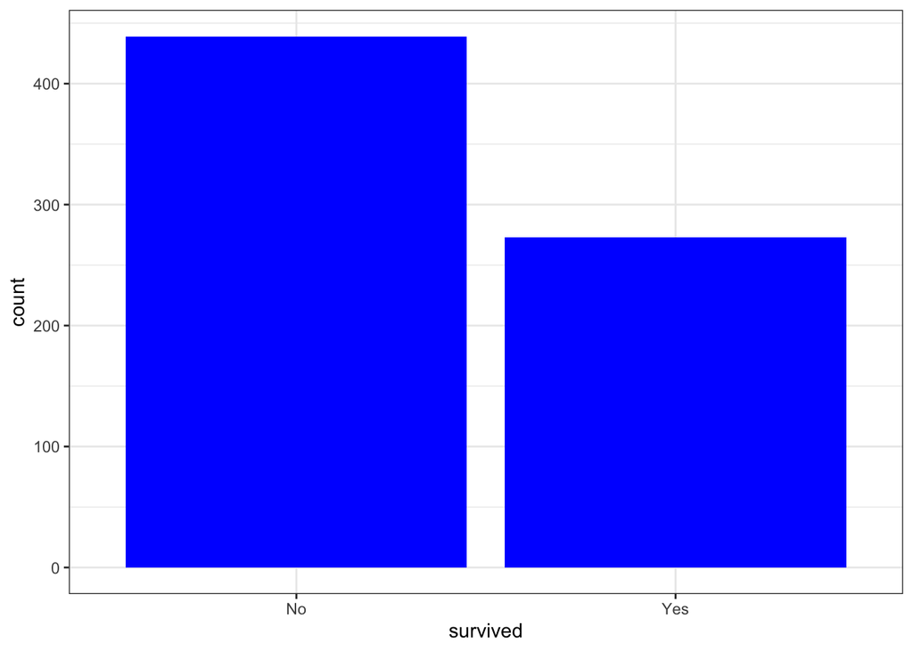

```r
titanic_train %>%
  ggplot(aes(x = survived)) +
  geom_bar(fill = "blue")+
  theme_bw()
```

## Question 3

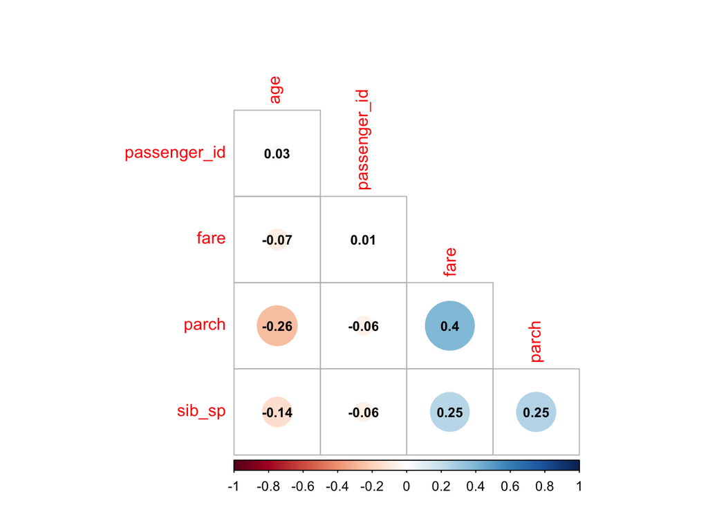

```r
#titanic_train <- drop_na(titanic_train)

corrplot(cor(drop_na(titanic_train) %>% dplyr:: select(passenger_id, sib_sp, parch, fare,age)) ,method = 'circle', type = 'lower', insig='blank', addCoef.col ='black', number.cex = 0.8, order = 'AOE', diag=FALSE)
```

## Question 4

```r
titanic_recipe <- recipe(survived ~ pclass + sex + age + sib_sp + parch + fare, data = titanic_train) %>%
  step_impute_linear(age, impute_with = imp_vars(pclass,sex)) %>%
  step_dummy(all_nominal_predictors()) %>%
  step_interact(terms = ~ starts_with("sex"):fare) %>%
  step_interact(terms = ~ age:fare)
```

## Question 5

```r
logit_model <- logistic_reg() %>% set_engine("glm") %>% set_mode("classification")

logit_workflow <- workflow() %>%  add_model(logit_model) %>%  add_recipe(titanic_recipe)

logit_fit <- fit(logit_workflow, titanic_train)

#logit_fit %>% tidy()
```

## Question 6

```r
lda_model <- discrim_linear()  %>% set_mode("classification") %>% set_engine("MASS")

lda_workflow <- workflow() %>%  add_model(lda_model) %>%  add_recipe(titanic_recipe)

lda_fit <- fit(lda_workflow, titanic_train)
```

## Question 7

```r
qda_model <- discrim_quad()  %>% set_mode("classification") %>% set_engine("MASS")

qda_workflow <- workflow() %>%  add_model(qda_model) %>%  add_recipe(titanic_recipe)

qda_fit <- fit(qda_workflow, titanic_train)
```

## Question 8

```r
nb_model <- naive_Bayes() %>% set_mode("classification") %>% set_engine("klaR") %>% set_args(usekernel = FALSE)

nb_workflow <- workflow() %>% add_model(nb_model) %>% add_recipe(titanic_recipe)

nb_fit <- fit(nb_workflow, titanic_train)
```

## Question 9

```r
#Prediction
logit_pred <-predict(logit_fit, new_data = titanic_train, , type = "prob")
lda_pred <-predict(lda_fit, new_data = titanic_train, , type = "prob")
qda_pred <-predict(qda_fit, new_data = titanic_train, , type = "prob")
nb_pred <-predict(nb_fit, new_data = titanic_train, , type = "prob")

#Accuracy
logit_acc <- augment(logit_fit, new_data = titanic_train) %>% accuracy(truth = survived, estimate = .pred_class)
lda_acc <- augment(lda_fit, new_data = titanic_train) %>% accuracy(truth = survived, estimate = .pred_class)
qda_acc <- augment(qda_fit, new_data = titanic_train) %>% accuracy(truth = survived, estimate = .pred_class)
nb_acc <- augment(nb_fit, new_data = titanic_train) %>% accuracy(truth = survived, estimate = .pred_class)

accuracies <- c(logit_acc$.estimate, lda_acc$.estimate, qda_acc$.estimate , nb_acc$.estimate)
models <- c("Logistic Regression", "LDA", "QDA", "Naive Bayes")
results <- tibble(accuracies = accuracies, models = models) %>% arrange(-accuracies)
results
```

```
## # A tibble: 4 × 2
##   accuracies models
##        <dbl> <chr>
## 1      0.817 Logistic Regression
## 2      0.809 QDA
## 3      0.805 LDA
## 4      0.777 Naive Bayes
```

We can see that logit achieves the highest the highest accuracy on the training data.

## Question 10

```r
#Because logit has the highest accuracy from the training set, I am going to fit logit with the test set
logit_pred_test <- predict(logit_fit, new_data = titanic_test, type = "prob")
logit_acc_test  <- augment(logit_fit, new_data = titanic_test) %>% accuracy(truth = survived, estimate = .pred_class)
logit_acc_test
```

```
## # A tibble: 1 × 3
##   .metric  .estimator .estimate
##   <chr>    <chr>          <dbl>
## 1 accuracy binary         0.782
```

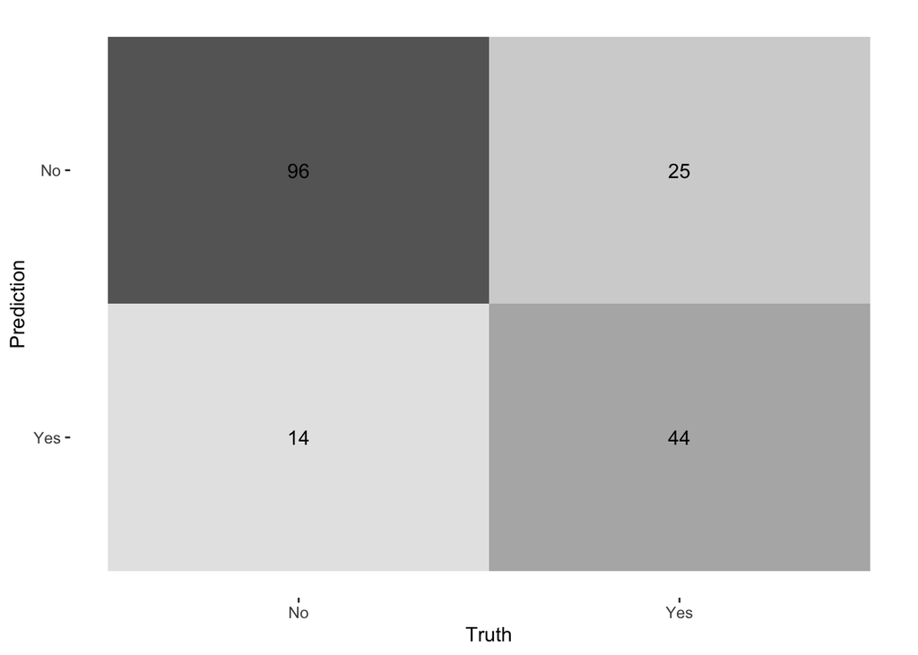

```r
#creating and visualizing the confusion matrix
augment(logit_fit, new_data = titanic_test) %>% conf_mat(truth = survived, estimate = .pred_class) %>% autoplot(type = "heatmap")
```

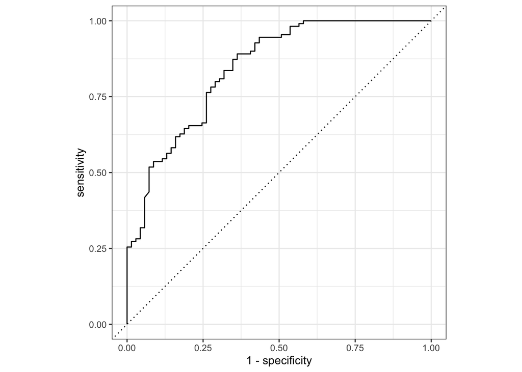

```r
#ROC curve
augment(logit_fit, new_data = titanic_test) %>%
  roc_curve(survived, .pred_No) %>%
  autoplot()
```

```r
#Area under the ROC curve
augment(logit_fit, new_data = titanic_test) %>%
  roc_auc(survived, .pred_No)
```

```
## # A tibble: 1 × 3
##   .metric .estimator .estimate
##   <chr>   <chr>          <dbl>
## 1 roc_auc binary         0.843
```

The test accuracy of the model is lower than the training accuracy of the model. This is not surprising because the model was trained with the training data. The area under the ROC curve is .84.

# 231 students only:

## Question 11

$p = \frac{e^z}{1+e^z}$. Multiplying both sides by $(\frac{1}{1-p})$ and taking the log, we get: $ln(\frac{p}{1-p}) = ln[\frac{e^z}{(1-p)(1+e^z)}]$. Plugging the value of p, we get:

$$ln(\frac{p}{1-p}) =
ln[\frac{e^z}{(1-(\frac{e^z}{1+e^z}))(1+e^z)}]$$
Then by simplifying, we have:
$$ln(\frac{p}{1-p}) =
z$$
.

## Question 12

Odds are equal to $\frac{p}{1-p} = exp\{\beta_0 + \beta_1x_1\}$. So the derivative in terms of $x_1$ is.
$$change\{odds\} = \beta_1exp\{\beta_0 +
\beta_1x_1\}$$
Therefore, if $x_1$ increases by 2, the odds increases by $\beta_1exp\{\beta_0 + \beta_1(2)\}$.

The formula for p is:
$$p =
\frac{exp\{\beta_0 + \beta_1x_1)\}}{1+exp\{\beta_0 + \beta_1x_1\}} =
\frac{1}{\frac{1}{exp\{(\beta_0 + \beta_1x_1)\}} + 1}$$

Thus, because $\beta$ is negative: as $x_1$ approaches $\infty$, p approaches 0, and as $x_1$ approaches $-\infty$, p approaches 1.